# Midterm

Hwang Seong-Yun

2022 4 28

# Beijing PM2.5 Data Data Set

- 본 데이터는 2010년 1월 1일부터 2014년 12월 31일까지 중국의 수도 베이징에서 측정한 대기관련 자료이며, 목적은 초미세먼지 농도를 측정하는 지표인 PM2.5에 어떠한 요인이 영향을 미치는지를 알아보는 데 있다.

## Description of variables

- No: row number
- year: year of data in this row
- month: month of data in this row
- day: day of data in this row
- hour: hour of data in this row
- pm2.5: PM2.5 concentration (ug/m^3)
- DEWP: Dew Point (â„ƒ)
- TEMP: Temperature (â„ƒ)
- PRES: Pressure (hPa)
- cbwd: Combined wind direction
- Iws: Cumulated wind speed (m/s)
- Is: Cumulated hours of snow
- Ir: Cumulated hours of rain

`-` 우선 분석의 목적과 관련이 없다고 여겨지는 변수인 No, year, month, day, hour, cbwd는 제거할 필요가 있다고 보여지며, 결측치(NA)가 포함된 관측치도 모두 제거한 뒤에 분석을 진행하고자 한다.

## Data loading

```r
PRSA <- read.csv("C:/Users/stat/Desktop/응용통계학/중간평가/PRSA.csv",sep=",",header=T)
PRSA <- na.omit(PRSA)[,-c(1,2,3,4,5,10)]
summary(PRSA)
```

```
##      pm2.5             DEWP             TEMP            PRES
##  Min.   :  0.00   Min.   :-40.00   Min.   :-19.0   Min.   : 991
##  1st Qu.: 29.00   1st Qu.:-10.00   1st Qu.:  2.0   1st Qu.:1008
##  Median : 72.00   Median :  2.00   Median : 14.0   Median :1016
##  Mean   : 98.61   Mean   :  1.75   Mean   : 12.4   Mean   :1016
##  3rd Qu.:137.00   3rd Qu.: 15.00   3rd Qu.: 23.0   3rd Qu.:1025
##  Max.   :994.00   Max.   : 28.00   Max.   : 42.0   Max.   :1046
##       Iws               Is                 Ir
##  Min.   :  0.45   Min.   : 0.00000   Min.   : 0.0000
##  1st Qu.:  1.79   1st Qu.: 0.00000   1st Qu.: 0.0000
##  Median :  5.37   Median : 0.00000   Median : 0.0000
##  Mean   : 23.87   Mean   : 0.05534   Mean   : 0.1949
##  3rd Qu.: 21.91   3rd Qu.: 0.00000   3rd Qu.: 0.0000
##  Max.   :565.49   Max.   :27.00000   Max.   :36.0000
```

### Multiple linear regression analysis

`1` 본 데이터에서 반응변수는 pm2.5($y$) 이고 이를 예측하기 위해 사용하는 설명변수는 DEWP($x_{1}$), TEMP($x_{2}$), PRES($x_{3}$), Iws($x_{4}$), Is($x_{5}$), Ir($x_{6}$) 이렇게 6가지이다.

`2` 다중회귀모형식은 다음과 같다.

- $y_{i}=\beta_{0}+\beta_{1}x_{1i}+\beta_{2}x_{2i}+\beta_{3}x_{3i}+\beta_{4}x_{4i}+\beta_{5}x_{5i}+\beta_{6}x_{6i}+\epsilon_{i}$
- 여기에 보통 $\epsilon_{i} \overset{i.i.d}{\sim} N(0,\sigma^{2})$ 이라는 가정을 하게 된다.
- 모형적합은 다음과 같이 할 수 있다.

```r
reg1 <- lm(pm2.5 ~ ., data=PRSA)
summary(reg1)
```

```
##
## Call:
## lm(formula = pm2.5 ~ ., data = PRSA)
##
## Residuals:
##     Min      1Q  Median      3Q     Max
## -163.00  -52.31  -15.68   33.09  874.89
##
## Coefficients:
##               Estimate Std. Error t value Pr(>|t|)
## (Intercept)  1.728e+03  7.299e+01  23.680  < 2e-16 ***
## DEWP         4.282e+00  5.346e-02  80.109  < 2e-16 ***
## TEMP        -6.068e+00  6.836e-02 -88.764  < 2e-16 ***
## PRES        -1.529e+00  7.135e-02 -21.431  < 2e-16 ***
## Iws         -2.616e-01  8.436e-03 -31.015  < 2e-16 ***
## Is          -2.267e+00  5.097e-01  -4.448  8.7e-06 ***
## Ir          -7.206e+00  2.816e-01 -25.593  < 2e-16 ***
## ---
## Signif. codes:  0 '***' 0.001 '**' 0.01 '*' 0.05 '.' 0.1 ' ' 1
##
## Residual standard error: 80.46 on 41750 degrees of freedom
## Multiple R-squared:  0.2361, Adjusted R-squared:  0.236
## F-statistic:  2151 on 6 and 41750 DF,  p-value: < 2.2e-16
```

- 위의 결과를 통해 다음과 같은 회귀모형식을 적을 수 있다.
- $\hat{y_{i}}=1728+4.282x_{1i}-6.068x_{2i}-1.529x_{3i}-0.262x_{4i}-2.267x_{5i}-7.206x_{6i}$
- 그리고 모든 설명변수에 대한 유의확률의 값이 유의수준 $\alpha=0.05$보다 작게 산출되는 것으로 보아서 본 모형에 적용한 모든 설명변수가 pm2.5의 변동을 설명하는 데 있어 유의한 영향력을 미치는 것으로 보여진다. 하지만, ${R_{adj}}^2=0.236$이므로 데이터의 변동에 대한 본 모형의 설명력이 그다지 크지는 않기 때문에 해석하는 데 있어 어느정도 주의가 필요할 것으로 보인다.
- 추정된 회귀모형식에 따르면 이슬점(DEWP)의 값이 증가할수록 pm2.5의 농도도 증가하게 된다. 하지만 온도(TEMP), 압력(PRES), 누적바람속도(Iws), 누적적설시간(Is), 누적강우시간(Ir)의 경우는 값이 감소할수록 pm2.5의 농도가 증가하는 것으로 보여진다.

`3` `2`를 통해 추정된 회귀모형이 잔차에 대한 가정(정규성, 등분산성, 독립성, 선형성)을 적절하게 만족하고 있는지 확인하기 위해 다음과 같이 할 수 있다.

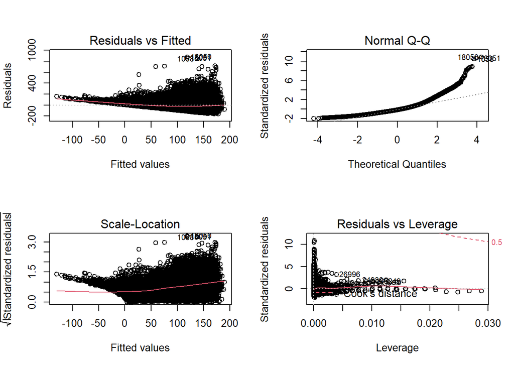

```r
par(mfrow=c(2,2))
plot(reg1)
```

```r
par(mfrow=c(1,1))
```

- 추가적으로 잔차의 등분산성에 대한 검정결과는 다음과 같다. (Score Test for Non-Constant Error Variance)

```r
library(car)
ncvTest(reg1)
```

```
## Non-constant Variance Score Test
## Variance formula: ~ fitted.values
## Chisquare = 6543.713, Df = 1, p = < 2.22e-16
```

- 검정결과 유의확률의 값이 굉장히 작게 나오므로 잔차가 등분산성을 만족한다고 할 수는 없다.
- 그리고 잔차의 정규성에 대한 검정결과는 다음과 같다. (Anderson-Darling test for normality)

```r
library(nortest)
ad.test(residuals(reg1))
```

```
##
##  Anderson-Darling normality test
##
## data:  residuals(reg1)
## A = 959.79, p-value < 2.2e-16
```

- 검정결과 등분산성 검정과 마찬가지로 유의확률의 값이 굉장히 작게 나오므로 잔차가 정규성을 만족한다고 할 수는 없다.
- 또한 잔차의 독립성에 대한 검정결과는 다음과 같다. (Durbin-Watson Test)

```r
require(lmtest)
dwtest(pm2.5 ~ ., data=PRSA)
```

```
##
##  Durbin-Watson test
##
## data:  pm2.5 ~ .
## DW = 0.10853, p-value < 2.2e-16
## alternative hypothesis: true autocorrelation is greater than 0
```

- 검정결과 이전의 검정과 마찬가지로 유의확률의 값이 굉장히 작게 나오므로 잔차가 독립성을 만족한다고 할 수는 없다.
- 위에 있는 잔차에 대한 4가지 plot을 살펴본 결과 본 회귀모형이 잔차에 대한 정규성, 등분산성, 독립성을 적절하게 만족하고 있지 않다고 보여지며, 이상점과 영향점도 존재하는 것으로 판단된다. 그러므로 다음과 같은 방법을 추가적으로 고려해보는 것이 좋을 것 같다.
- 1. 이상점의 특성을 살펴보고 데이터의 특성을 적절히 반영하지 않는다고 생각되면 이를 제거한다. 그렇지 않고 자연스러운 데이터의 생성과정에서 발생한 것이라면 robust method 등을 적용해본다.
- 2. 이분산성과 비선형 추세가 보임에 따라 반응변수와 설명변수에 대해 적절한 변환을 실시해본다.
- 3. Q-Q plot을 보면 극단적인 지점에서 Heavy-tail의 형태가 보이므로 bootstrap이나 permutation test와 같은 방법을 적용해본다.

`4` 추정된 회귀모형에서 다중공선성(multicollinearity), 즉 설명변수들 사이에 연관성이 존재하는지 확인해보기 위해 다음과 같이 VIF(Variance Inflation Factor)를 계산해볼 수 있다.

```r
library(car)
vif(reg1)
```

```
##     DEWP     TEMP     PRES      Iws       Is       Ir
## 3.839866 4.468608 3.484383 1.130163 1.016560 1.028599
```

- 분석결과 VIF의 값이 10을 초과하는 경우가 없으므로 다중공선성의 문제는 없다고 할 수 있겠다.

`5` 본 모형에 대하여 각 회귀계수에 대한 이론적인 95% 신뢰구간은 다음과 같이 계산된다.

```r
confint(reg1, level=0.95)
```

```
##                    2.5 %       97.5 %
## (Intercept) 1585.3694634 1871.4932061
## DEWP           4.1774357    4.3869808
## TEMP          -6.2020920   -5.9341101
## PRES          -1.6689905   -1.3892916
## Iws           -0.2781764   -0.2451066
## Is            -3.2658983   -1.2679012
## Ir            -7.7582516   -6.6544475
```

- 사실 위의 결과는 잔차에 대한 가정이 만족되지 않는 모형에 대하여 계산된 결과이기 때문에 신뢰하기는 어렵다고 여겨진다. 이러한 점을 고려하여 bootstrap 방법을 기반으로 하여 회귀계수의 95% 신뢰구간을 계산하는 방법을 생각해보도록 한다.

```r
X <- cbind(as.matrix(rep(1,nrow(PRSA))),as.matrix(PRSA[,-1]))
y <- as.matrix(PRSA[,1])
hat_beta <- solve(t(X)%*%X)%*%t(X)%*%y
```

```r
B=2000 ; M=1000
n <- nrow(PRSA)
beta_boots <- matrix(NA,nrow=7,ncol=B)
set.seed(1)

for (i in 1:B) {
  id_boot <- sample(1:n, replace=T)
  X_boot <- X[id_boot,]
  y_boot <- y[id_boot]
  beta_boot <- solve(t(X_boot)%*%X_boot)%*%t(X_boot)%*%y_boot
  beta_boots[,i] <- beta_boot
}

rownames(beta_boots) <- c('Intercept','DEWP','TEMP','PRES','Iws','Is','Ir')
```

`-` 변수 DEWP

```r
# Theoretical C.I.
confint(reg1, 'DEWP', level=0.95)
```

```
##         2.5 %   97.5 %
## DEWP 4.177436 4.386981
```

```r
# Bootstrap C.I. (normal interval)
c(hat_beta[2]-qnorm(0.975)*sd(beta_boots[2,]),hat_beta[2]+qnorm(0.975)*sd(beta_boots[2,]))
```

```
## [1] 4.190798 4.373619
```

```r
# Bootstrap C.I. (Pivotal interval)
c(2*hat_beta[2]-quantile(beta_boots[2,],probs=0.975),2*hat_beta[2]-quantile(beta_boots[2,],probs=0.025))
```

```
##    97.5%     2.5%
## 4.191664 4.371448
```

```r
# Bootstrap C.I. (Percentile interval)
c(quantile(beta_boots[2,],probs=0.025),quantile(beta_boots[2,],probs=0.975))
```

```
##     2.5%    97.5%
## 4.192969 4.372753
```

`-` 변수 TEMP

```r
# Theoretical C.I.
confint(reg1, 'TEMP', level=0.95)
```

```
##          2.5 %   97.5 %
## TEMP -6.202092 -5.93411
```

```r
# Bootstrap C.I. (normal interval)
c(hat_beta[3]-qnorm(0.975)*sd(beta_boots[3,]),hat_beta[3]+qnorm(0.975)*sd(beta_boots[3,]))
```

```
## [1] -6.213607 -5.922595
```

```r
# Bootstrap C.I. (Pivotal interval)
c(2*hat_beta[3]-quantile(beta_boots[3,],probs=0.975),2*hat_beta[3]-quantile(beta_boots[3,],probs=0.025))
```

```
##     97.5%      2.5%
## -6.209886 -5.920744
```

```r
# Bootstrap C.I. (Percentile interval)
c(quantile(beta_boots[3,],probs=0.025),quantile(beta_boots[3,],probs=0.975))
```

```
##      2.5%     97.5%
## -6.215458 -5.926316
```

`-` 변수 PRES

```r
# Theoretical C.I.
confint(reg1, 'PRES', level=0.95)
```

```
##         2.5 %    97.5 %
## PRES -1.66899 -1.389292
```

```r
# Bootstrap C.I. (normal interval)
c(hat_beta[4]-qnorm(0.975)*sd(beta_boots[4,]),hat_beta[4]+qnorm(0.975)*sd(beta_boots[4,]))
```

```
## [1] -1.677948 -1.380334
```

```r
# Bootstrap C.I. (Pivotal interval)
c(2*hat_beta[4]-quantile(beta_boots[4,],probs=0.975),2*hat_beta[4]-quantile(beta_boots[4,],probs=0.025))
```

```
##     97.5%      2.5%
## -1.676051 -1.374395
```

```r
# Bootstrap C.I. (Percentile interval)
c(quantile(beta_boots[4,],probs=0.025),quantile(beta_boots[4,],probs=0.975))
```

```
##      2.5%     97.5%
## -1.683887 -1.382232
```

`-` 변수 Iws

```r
# Theoretical C.I.
confint(reg1, 'Iws', level=0.95)
```

```
##          2.5 %     97.5 %
## Iws -0.2781764 -0.2451066
```

```r
# Bootstrap C.I. (normal interval)
c(hat_beta[5]-qnorm(0.975)*sd(beta_boots[5,]),hat_beta[5]+qnorm(0.975)*sd(beta_boots[5,]))
```

```
## [1] -0.2730267 -0.2502562
```

```r
# Bootstrap C.I. (Pivotal interval)
c(2*hat_beta[5]-quantile(beta_boots[5,],probs=0.975),2*hat_beta[5]-quantile(beta_boots[5,],probs=0.025))
```

```
##      97.5%       2.5%
## -0.2729561 -0.2504185
```

```r
# Bootstrap C.I. (Percentile interval)
c(quantile(beta_boots[5,],probs=0.025),quantile(beta_boots[5,],probs=0.975))
```

```
##       2.5%      97.5%
## -0.2728644 -0.2503268
```

`-` 변수 Is

```r
# Theoretical C.I.
confint(reg1, 'Is', level=0.95)
```

```
##        2.5 %    97.5 %
## Is -3.265898 -1.267901
```

```r
# Bootstrap C.I. (normal interval)
c(hat_beta[6]-qnorm(0.975)*sd(beta_boots[6,]),hat_beta[6]+qnorm(0.975)*sd(beta_boots[6,]))
```

```
## [1] -3.153276 -1.380523
```

```r
# Bootstrap C.I. (Pivotal interval)
c(2*hat_beta[6]-quantile(beta_boots[6,],probs=0.975),2*hat_beta[6]-quantile(beta_boots[6,],probs=0.025))
```

```
##     97.5%      2.5%
## -3.140889 -1.384040
```

```r
# Bootstrap C.I. (Percentile interval)
c(quantile(beta_boots[6,],probs=0.025),quantile(beta_boots[6,],probs=0.975))
```

```
##      2.5%     97.5%
## -3.149759 -1.392910
```

`-` 변수 Ir

```r
# Theoretical C.I.
confint(reg1, 'Ir', level=0.95)
```

```
##        2.5 %    97.5 %
## Ir -7.758252 -6.654447
```

```r
# Bootstrap C.I. (normal interval)
c(hat_beta[7]-qnorm(0.975)*sd(beta_boots[7,]),hat_beta[7]+qnorm(0.975)*sd(beta_boots[7,]))
```

```
## [1] -7.684787 -6.727912
```

```r
# Bootstrap C.I. (Pivotal interval)
c(2*hat_beta[7]-quantile(beta_boots[7,],probs=0.975),2*hat_beta[7]-quantile(beta_boots[7,],probs=0.025))
```

```
##     97.5%      2.5%
## -7.663201 -6.686206
```

```r
# Bootstrap C.I. (Percentile interval)
c(quantile(beta_boots[7,],probs=0.025),quantile(beta_boots[7,],probs=0.975))
```

```
##      2.5%     97.5%
## -7.726493 -6.749498
```

- 결과를 보면 이론적인 결과와 bootstrap에 의한 결과가 비슷하게 나오는 변수도 있지만 Is, Ir처럼 차이가 나는 변수도 있다. 추정한 회귀모형이 잔차에 대한 가정을 만족하지 못하고 있는 것이 주된 이유로 보인다.